```python
from IPython.display import Image
```

# Fairness - Theory

## Fairness - Introduction

In Module I - Data Quality, we discussed the concept of bias in data. One example provided was of how Amazon had built a hiring AI tool that discriminated against women.

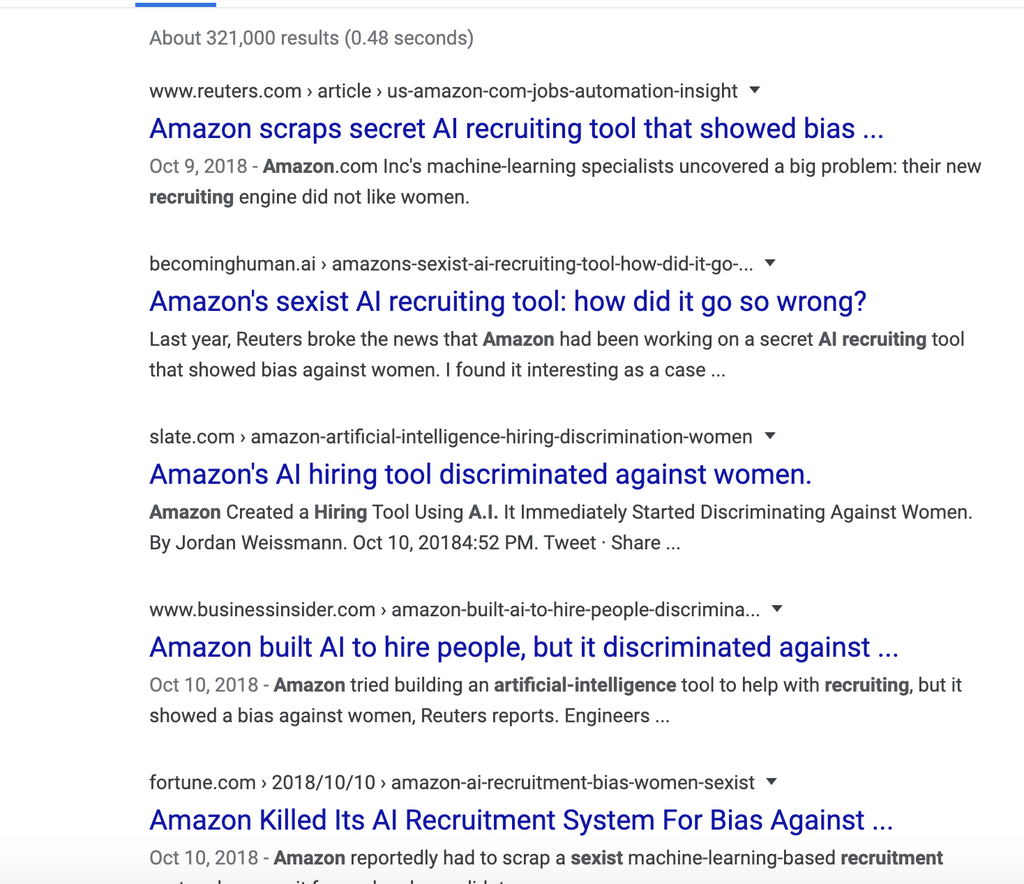

```python
Image('img/amazon_hire.png')
```

A downside to ML models is that a machine does not know the nuances of race, gender, etc. In Amazon's hiring tool, all of the math was correct! But because of how the ML model was trained -- an issue within the data itself -- it skewed towards men over women. This issue then compounded as only more men were added to the data that the model was built on as more hiring decisions were made.

What does it mean for an ML model to be **fair**?

This is a huge debate and there are many decisions. It is impossible to satisfy all fairness decisions. Here are some of them:

- Unawareness
- Demographic Parity
- Accuracy Parity / Equalized Odds
- Precision Parity / Predictive Rate Parity

In the explanations below, we will visualize each of these fairness metrics from the perspective of Amazon hiring people who identify as males or females.

## Unawareness

A classifier $C$ satisfies unawareness if:

- $P(C(X,A) = 1) = P(C(X) = 1)$
  - i.e. A does not affect the prediction
  - Useless since $X$ is usually highly correlated with $A$

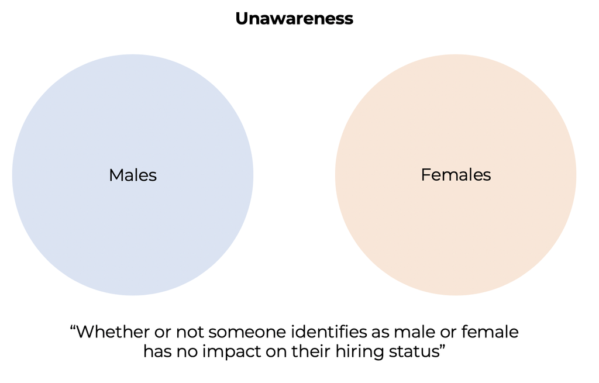

```python
Image("img/unawareness.png")
```

## Demographic Parity

A classifier $C$ satisifies demographic parity if:

- $P(C(X,A) = 1 | A =1) = P(C(X,A) = 1 | A = 0)$
  - i.e. Probability of success does not change, conditional on a sensitive attribute $A$ (e.x. hiring rates of applicants from two groups must be equal)
  - Ignores any possible correlation between $Y$ and $A$
  - Demographic parity is also easy to satisfy with trivial classifiers

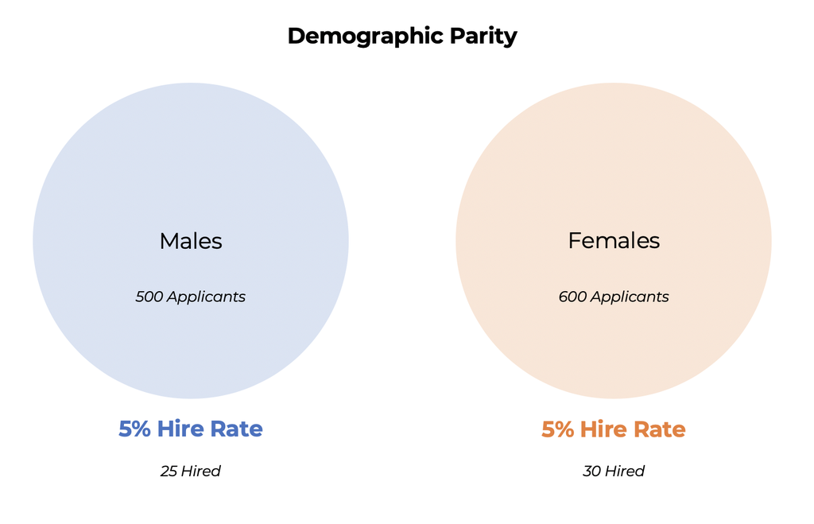

```python
Image("img/demographic_parity.png")
```

## Accuracy Parity / Equalized Odds

A classifer $C$ satsifies accuracy parity (also known as equalized odds) if:

- $P(C(X,A)=Y|A=1)=P(C(X,A)=Y|A=0)$
  - i.e. Probability that a prediction is correct does not change, conditional on sensitive attribute $A$ (e.x. hire equal proportion of indivduals from the qualified portion of each group)
  - However, this equally weighs false positives and false negatives, which do not always have the same consequence (e.x. consider a false positive vs a false negative for likelihood to re-offend after prison)

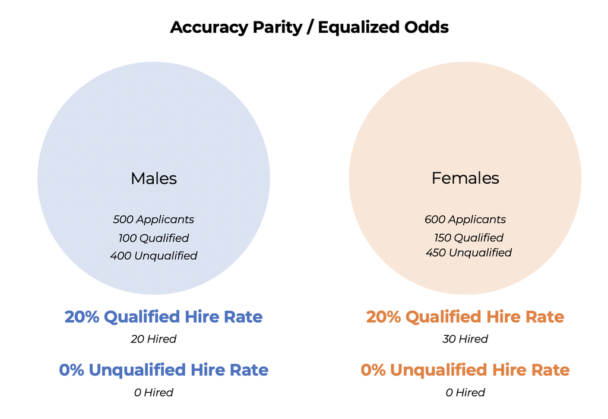

```python
Image("img/accuracy_parity.png")
```

## Precision Parity / Predictive Rate Parity

A classifier $C$ satisifies precision parity (also known as predictive rate parity) if:

- $P(Y=1|C=1, A=1) = P(Y=1|C=1, A=0)$
  - The prediction of success matches realized success (e.x. predicts a good hire, and actually is a good hire)
  - However, doesn't necessarily lead to more sucessful predictions, just more precise

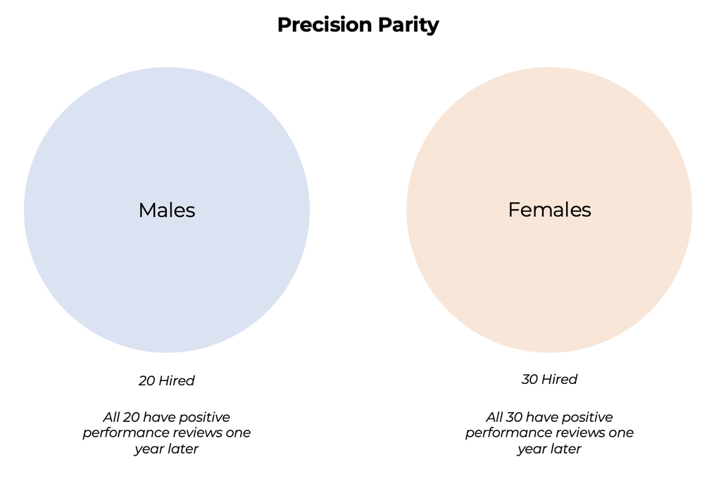

```python
Image("img/precision_parity.png")
```

## How do we decide on what it means for our model to be fair?

It is not our responsibility to decide this, unless we are representative of the group the model is impacting. Rather, it is our responsibility to listen to all the voices impacted and implement based off of that.

- Most likely, the people who developed Amazon's hiring tool were mostly male (an unfortunate trend in the field) and so never caught this or thought about evaluating their model appropriately
- They should have hired women on their team, or at minimum speak with women to understand how to work towards a fair algorithm

In other words, be aware of your stakeholders and actively discuss and critique any developed algorithms with them.

## More Resources

[More In-Depth Article on Fairness](https://towardsdatascience.com/a-tutorial-on-fairness-in-machine-learning-3ff8ba1040cb)